# AFL Betting Schemes

## Data

The file ‘AFLOdds.csv’ contains the final score, and odds set by a bookmaker for 1158 games of AFL played between 2009 and 2015. The data was imported, and the ‘tidyverse’ and ‘knitr’ libraries were used for data frame manipulation, tables, and plots.

```r
# Clears memory, load required packages, and displays working directory.
rm(list = ls())

library(tidyverse)
library(knitr)

getwd()
```

```r
# Load AFL Data into data frame
AFLOdds <- read_csv("AFLOdds.csv")
```

# Part 1

## (i) Betting Rules

Firstly, we must evaluate the expected net return per game for each of the four simple betting rules:

1. Always bet on the ‘Home’ team
2. Always bet on the ‘Away’ team
3. Always bet on the ‘favourite’ team (the team with lowest odds)
4. Always bet on the ‘non-favourite’ team (the team with highest odds)

Net winnings for a game are calculated as follows:  
suppose you bet 1 dollar on a team winning with odds $x$. If the team wins, your net winnings are $x-1$ dollars.  
However if the team loses, your winnings are -1 dollar.

The net winnings for each game, for each betting rule (1-4) were calculated, and a new column was added to the data frame for each of the four strategies.

```r
# Adds column for payouts for 'Home' bet for each game
AFLOdds <- AFLOdds %>%
  mutate(Home_Bet = ifelse(Home_Score > Away_Score, Home_Odds-1, -1))

# Adds column for payouts for 'Away' bet for each game
AFLOdds <- AFLOdds %>%
  mutate(Away_Bet = ifelse(Away_Score > Home_Score, Away_Odds-1, -1))


# Adds column for payouts for 'favourite' bet for each game
AFLOdds <- AFLOdds %>%
  mutate(Favourite_Bet = ifelse(Home_Odds < Away_Odds,
                                ifelse(Home_Score > Away_Score, Home_Odds-1, -1),   # Home is favourite
                                ifelse(Away_Score > Home_Score, Away_Odds-1, -1)))  # Away is favourite

# Adds column for payouts for 'non-favourite' bet for each game
AFLOdds <- AFLOdds %>%
  mutate(Nonfavourite_Bet = ifelse(Home_Odds < Away_Odds,
                                ifelse(Home_Score > Away_Score, -1, Away_Odds-1),   # Home is favourite
                                ifelse(Away_Score > Home_Score, -1, Home_Odds-1)))  # Away is favourite
```

## (ii) Expected Net Winnings Per Game

To calculate the net winnings per game, a new data frame was created. The mean ($\overline{x}$) net winnings for each betting rule was calculated, along with the standard deviation ($\sigma$). Approximate standard errors ($\sigma_{\overline{x}}$) for these means were calculated using $\frac{\sigma}{\sqrt n}$, and approximate 95% confidence intervals for the means were calculated from these standard error values ($\overline{x} \pm 2\sigma_{\overline{x}}$).

```r
# Builds a data frame with data for each betting strategy
# Firstly calculates the means and standard deviations for each betting strategy
n = nrow(AFLOdds)
Rules = c("Home", "Away", "Favourite", "Non-favourite")
Rule_Mean = c(mean(AFLOdds$Home_Bet), mean(AFLOdds$Away_Bet), mean(AFLOdds$Favourite_Bet), mean(AFLOdds$Nonfavourite_Bet))
Rule_sd = c(sd(AFLOdds$Home_Bet), sd(AFLOdds$Away_Bet), sd(AFLOdds$Favourite_Bet), sd(AFLOdds$Nonfavourite_Bet))
df_Rules=data.frame(Rules, Rule_Mean, Rule_sd)

# Instantiates new data frame using calculated means, standard deviations,
# then computes approximate standard errors for the means,
# and an approximate 95% confidence interval for the means.
df_Rules <- df_Rules %>%
  mutate(SEM = Rule_sd/sqrt(n)) %>%
  mutate(CILow = Rule_Mean - 2*SEM) %>%
  mutate(CIHigh = Rule_Mean + 2*SEM)
```

## (iii) Results Of Simple Betting Strategies

By examining the ‘Rule_Mean’ column of this table, we can see that all of the betting strategies had negative expected net returns per game.

```r
kable(df_Rules)
```

| Rules | Rule_Mean | Rule_sd | SEM | CILow | CIHigh |
| --- | --- | --- | --- | --- | --- |
| Home | -0.0352763 | 1.1896402 | 0.0349592 | -0.1051947 | 0.0346420 |
| Away | -0.1583161 | 1.2999408 | 0.0382005 | -0.2347171 | -0.0819150 |
| Favourite | -0.0604491 | 0.6283845 | 0.0184659 | -0.0973809 | -0.0235172 |
| Non-favourite | -0.1026511 | 1.6673973 | 0.0489987 | -0.2006486 | -0.0046537 |

That is:

1. Betting on the home team was an average net loss of approximately $0.0353 per game (3.53%).
2. Betting on the away team was an average net loss of approximately $0.1583 per game (15.83%).
3. Betting on the favourite team was an average net loss of approximately $0.0604 per game (6.04%).
4. Betting on the non-favourite team was an average net loss of approximately $0.1027 per game (10.27%).

By examining the table above, and the plot below, we can clearly see that none of the betting strategies have a positive expected net winnings. However, it is clear that the ‘best’ simple strategy is number 1; betting on the home team (for an average loss of approximately 3.53% per game).

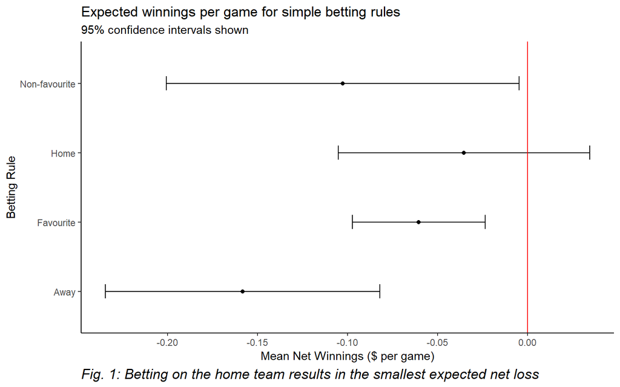

```r
# Plots mean return per game for each betting strategy
ggplot(df_Rules, aes(x = Rules, y = Rule_Mean)) +
  geom_point(shape=19) +
  geom_errorbar(aes(x = Rules, ymin = Rule_Mean - 2*SEM,
                    ymax = Rule_Mean + 2*SEM), width=0.2) +
  labs(title = "Expected winnings per game for simple betting rules",
       subtitle = "95% confidence intervals shown",
       caption = "Fig. 1: Betting on the home team results in the smallest expected net loss",
       x = "Betting Rule", y = "Mean Net Winnings ($ per game)") +
  geom_hline(yintercept=0, color = "red") +
  theme_classic() +
  theme(plot.caption = element_text(size = 13, face = "italic", hjust = 0)) +
  coord_flip() # flip the x and y axes
```

# Part 2

## (i) Alternative Betting Strategy

Each of the four simple strategies resulted in an expected net loss per game. However, the expected net loss was smallest for Rule 1 (betting on the home team).

As a result, another rule was considered:

5. Bet on a particular team only when playing at home.

A new data frame (df_Teams) was constructed by grouping each team, and calculating expected winnings from bets placed on home games only.

```r
# Group by home team
df_Teams <- AFLOdds %>%
  group_by(Home_Team) %>%
  summarise(
    Games = n(),
    Home_Mean = mean(Home_Bet),
    Home_sd = sd(Home_Bet),
    SEM = Home_sd / sqrt(Games),
    CILow = Home_Mean - 2*SEM,
    CIHigh = Home_Mean + 2*SEM
  )
```

## (ii) Expected Net Winnings Per Game

Mean, standard deviation, standard error of the mean, and confidence intervals of net winnings (per game) were calculated as in Part 1. (ii) for each of the 18 teams.

## (iii) Results Of Betting Rule 5

From the table below, we can see that several teams - Adelaide, Essendon, Fremantle, Geelong, Gold Coast, Hawthorn, North Melbourne, and Port Adelaide - have a positive mean net winnings per game.

```r
kable(df_Teams)
```

| Home_Team | Games | Home_Mean | Home_sd | SEM | CILow | CIHigh |
| --- | --- | --- | --- | --- | --- | --- |
| Adelaide | 67 | 0.0604478 | 1.0110427 | 0.1235185 | -0.1865893 | 0.3074848 |
| Brisbane | 65 | -0.0150769 | 1.4422510 | 0.1788892 | -0.3728554 | 0.3427015 |
| Carlton | 67 | -0.2814925 | 0.9793539 | 0.1196471 | -0.5207868 | -0.0421983 |
| Collingwood | 74 | -0.0100000 | 0.7153311 | 0.0831556 | -0.1763111 | 0.1563111 |
| Essendon | 64 | 0.0892188 | 1.5160845 | 0.1895106 | -0.2898024 | 0.4682399 |
| Fremantle | 67 | 0.0550746 | 0.7391772 | 0.0903049 | -0.1255351 | 0.2356844 |
| Geelong | 73 | 0.1589041 | 0.5696455 | 0.0666720 | 0.0255602 | 0.2922480 |
| Gold Coast | 47 | 0.0963830 | 2.3382523 | 0.3410691 | -0.5857553 | 0.7785213 |
| GWS Giants | 36 | -0.0647222 | 2.1763869 | 0.3627311 | -0.7901845 | 0.6607401 |
| Hawthorn | 71 | 0.0987324 | 0.5469916 | 0.0649160 | -0.0310995 | 0.2285643 |
| Melbourne | 64 | -0.3835938 | 1.0567431 | 0.1320929 | -0.6477795 | -0.1194080 |
| North Melbourne | 63 | 0.0952381 | 1.1159140 | 0.1405919 | -0.1859458 | 0.3764220 |
| Port Adelaide | 64 | 0.0804687 | 1.3737984 | 0.1717248 | -0.2629808 | 0.4239183 |
| Richmond | 65 | -0.2558462 | 0.9999217 | 0.1240250 | -0.5038962 | -0.0077961 |
| St Kilda | 68 | -0.0019118 | 1.6692712 | 0.2024289 | -0.4067695 | 0.4029460 |
| Sydney | 71 | -0.1095775 | 0.7362112 | 0.0873722 | -0.2843219 | 0.0651669 |
| West Coast | 66 | -0.1221212 | 0.7848675 | 0.0966105 | -0.3153422 | 0.0710998 |
| Western Bulldogs | 66 | -0.1292424 | 1.0600179 | 0.1304792 | -0.3902008 | 0.1317159 |

However, when the expected net winnings are plotted with approximate 95% confidence intervals, we can see that this is potentially misleading.

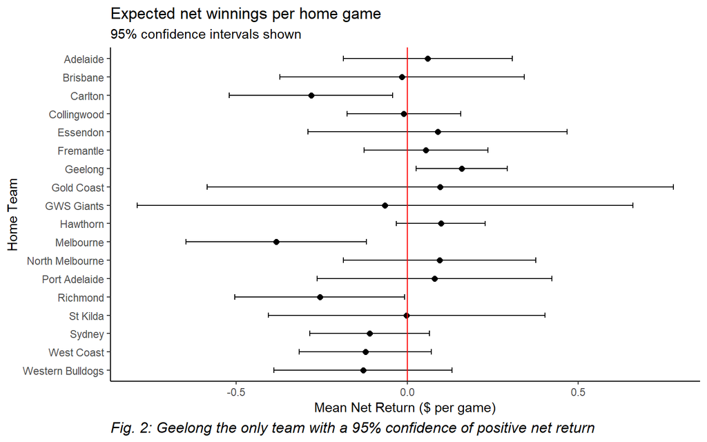

```r
df_Teams$Home_Team <- factor(df_Teams$Home_Team, levels=rev(df_Teams$Home_Team)) # reverses alphabetical order, so in correct order when coords flipped
# Plots mean net return per home game for each team, and standard error of the mean (95% CI)
ggplot(df_Teams, aes(,x = Home_Team, y = Home_Mean)) +
  geom_point(shape=16, size=2) +
  geom_errorbar(aes(x = Home_Team, ymin = Home_Mean - 2*SEM,
                    ymax = Home_Mean + 2*SEM), width=0.3) +
  labs(title = "Expected net winnings per home game", subtitle = "95% confidence intervals shown",
       caption = "Fig. 2: Geelong the only team with a 95% confidence of positive net return",
       x = "Home Team", y = "Mean Net Return ($ per game)") +
  geom_hline(yintercept=0, color = "red") +
  theme_classic() +
  theme(plot.caption = element_text(size = 12, face = "italic", hjust = 0)) +
  coord_flip() # flip the x and y axes
```

Additionally, if one was willing to accept slightly more risk, Hawthorn deserves consideration. Hawthorn’s expected winnings as the home team were 0.0987 (9.87%), However, the low end of Hawthorn’s 95% confidence interval was -0.0311 (-3.11%), indicating a small probability of losing money.

It is interesting to note that these are the two teams with the lowest standard error of the mean. This, combined with their relatively higher number of games played (in comparison to some other teams) might indicate more finals games, and hence a better performance (and more games won) during the season.

## Closing Remarks

While this analysis suggests it might seem a sensible option to place bets on Geelong (and perhaps Hawthorn) at home, it should be noted that past performance cannot be used to accurately determine future performance.

The author does not endorse gambling of any kind.

Zac Greene

14/03/2019